# Mayo Clinic Yelp Review Text Analysis

RexManglicmot

## Status: Working project

Hi everyone. I’m continuing building my data analysis and R skills. As such, I would love feedback to better improve this project via rexmanglicmot@gmail.com. Any mistakes and misrepresentation of the data are my own.

Things Need to Do:

1. Head function on the text column shows only the 5th observation’s text but not the others. Need to figure out why. I used the count function on text column and it shows 228 observations. Maybe this is an RStudio issue?
2. Need to create word clouds
3. Import and adjust dictionaries
4. Fix grammar

## Introduction

To gain a better understanding why the Mayo Clinic is #1, I decided to use a Text Analysis on comments made by Yelp reviewers. Thus, this projects aims to understand user reviews through the Yelp platform, which is aimed to provide reviews to many businesses, including healthcare institutions (both private and public).

This project is comprised of the following chapters:

1. Webscraping Yelp Data
2. Cleaning data
3. EDA the Data
4. Visualizations
5. Plotting Word Cloud
6. Plotting

## Webscraping Yelp Data

There were 228 reviews in total and the goal was to scrape all 228 reviews containing 4 metrics:

1. reviewer name
2. reviewer location
3. review rating
4. review text

After various hours debugging the code and looking at html tags to discern appropiate tags to scrape, I was able to obtain all reviews within Yelp. Troubleshooting code included unintentionally scraping a response from a Mayo Clinic official that accrued in more than the 228 reviews.

Nonetheless, below is the code used to scrape data. Mayo_Clinic file is available within the repository.

```r
#load libraries
library(tidyverse)
library(rvest)

#create an object to store the webpage address
url <- 'https://www.yelp.com/biz/mayo-clinic-rochester-12?osq=Mayo+clinic'

#convert the url to an html object for R processing
webpage <- read_html(url)

#create object to know page number on the webpage
webpageNum <- webpage %>%
  html_elements(xpath = "//div[@class= ' border-color--default__09f24__NPAKY text-align--center__09f24__fYBGO']") %>%
  html_text() %>%
  str_extract('of.*') %>%
  str_remove('of ') %>%
  as.numeric()

#create a sequence to iterate for page number
webpageSeq <- seq(from = 0, to = (webpageNum * 10)-10, by = 10)

#store items into empty objects
reviewer_name_all = c()
reviewer_location_all = c()
review_rating_all = c()
review_text_all = c()

#create a for loop to get values throughout the 23 pages
for (i in webpageSeq) {
  #need to create an if statement because the 1st page web address
  if (i == 0) {
    webpage <- read_html(url)
    #need to create else because webpage has more content than 1st page web
    #address
  } else {
    webpage <- read_html(paste0(url, '&start=', i))
  }

  #reviewer name
  reviewer_name <- webpage %>%
    #return elements that I specify via xpath method
    #xpath is useful for locating elements
    #// means to search within entire document
    #* means to return any of the elements
    # div means to search within document with the div tags
    html_elements(xpath = "//div[starts-with(@class,' user-passport')]") %>%
    #look within a tag within the previous element
    html_elements(xpath = ".//a[starts-with(@href, '/user_details')]") %>%
    html_text()

  #reviewer location
  reviewer_location <- webpage %>%
    #location is within the same div tag, so use same code
    html_elements(xpath = "//div[starts-with(@class,' user-passport')]") %>%
    #location is also located within the span tag
    html_elements(xpath = ".//span[@class= ' css-qgunke']") %>%
    html_text() %>%
    #remove "Location"
    #pipe remaining values that are not "Location"
    .[. !='Location']

  #review rating
  review_rating <- webpage %>%
    html_elements(xpath = "//div[starts-with(@class, ' review')]") %>%
    #within div tag there is an aria-label
    #contains function to look for aria-label that has rating
    html_elements(xpath = "(.//div[contains(@aria-label, 'star rating')])[1]")%>%
    #ratings are not text, so must use different method and specify which
    #attribute to obtain
    html_attr('aria-label') %>%
    #remove star rating
    str_remove_all(' star rating') %>%
    #convert into a numeric
    as.numeric()

  #review text
  review_text <- webpage %>%
    html_elements(xpath = "//div[starts-with(@class, ' review')]") %>%
    #look throughout webpage with the p tag
    #to get the first comment and not worr about business comment,
    #need to put in brackets
    html_elements(xpath = "(.//p[starts-with(@class, 'comment')])[1]") %>%
    #html_elements(xpath = ".//span[starts-with(@class, ' raw')]") %>%
    html_text()

  #appending to appropriate objects
  reviewer_name_all = append(reviewer_name_all, reviewer_name)
  reviewer_location_all = append(reviewer_location_all, reviewer_location)
  review_rating_all = append(review_rating_all, review_rating)
  review_text_all = append(review_text_all, review_text)

}

#create a dataframe containing appended values
Mayo_Clinic <- data.frame('name' = reviewer_name_all,
                          'location' = reviewer_location_all,
                          'rating' = review_rating_all,
                          'text'= review_text_all)

#view csv file
#head(Mayo_Clinic)
```

## EDA the Data

Next, I needed to load packages, load data, and run an intital analysis on the raw data to better.

```r
#load libraries
#install.packages('tidyverse') #had to re-install for some reason on 11/12/22
#install.packages('ggraph') #had to re-install for some reason on 11/12/22
#install.packages('DT')

library(tidyverse)
library(tidytext)
library(widyr)
library(RColorBrewer)
library(wordcloud)
library(igraph)
library(ggraph)
library(DT)
```

Now, let load the data. Instead of using the function str, let’s expand my R code competency by using different functions

```r
#load Mayo Clinic data
data <- read.csv('Mayo_Clinic.csv')

#get the names of the variables
colnames(data)

#get the number of rows in the dataset
dim(data)
```

[output not shown]

```r
install.packages('DT')
```

```r
#View first 10 observations of the data
#BUG why does it only show the 5th's obersvations text?
#it shows perfectly fine on RStudio
head(data, 15)

#how many observations are in the text column
length(data$text)
```

[output not shown]

```r
#load Mayo Clinic data
data <- read.csv('Mayo_Clinic.csv')

#get the names of the variables
colnames(data)
```

```
[1] "X"        "name"     "location" "rating"   "text"
```

```r
#get the number of rows in the dataset
dim(data)
```

```
[1] 228   5
```

```r
#quick check to see if reviewer_name appears more than once
data %>%
  count(name, sort = TRUE)
```

[output not shown]

5 people reviewed twice.

```r
#quick check to see and sum if any NA are in rating variable
sum(is.na(data$rating))
```

```
[1] 0
```

```r
#calculate summary statistics
summary(data$rating)
```

```
   Min. 1st Qu.  Median    Mean 3rd Qu.    Max.
   1.00    1.00    5.00    3.39    5.00    5.00
```

Looking at the summary statistics we see that the median and the max of the list is 5. What this means is that there are more of the 5 “ratings” in the list than there are others. The best way to view this, is via the barchart.

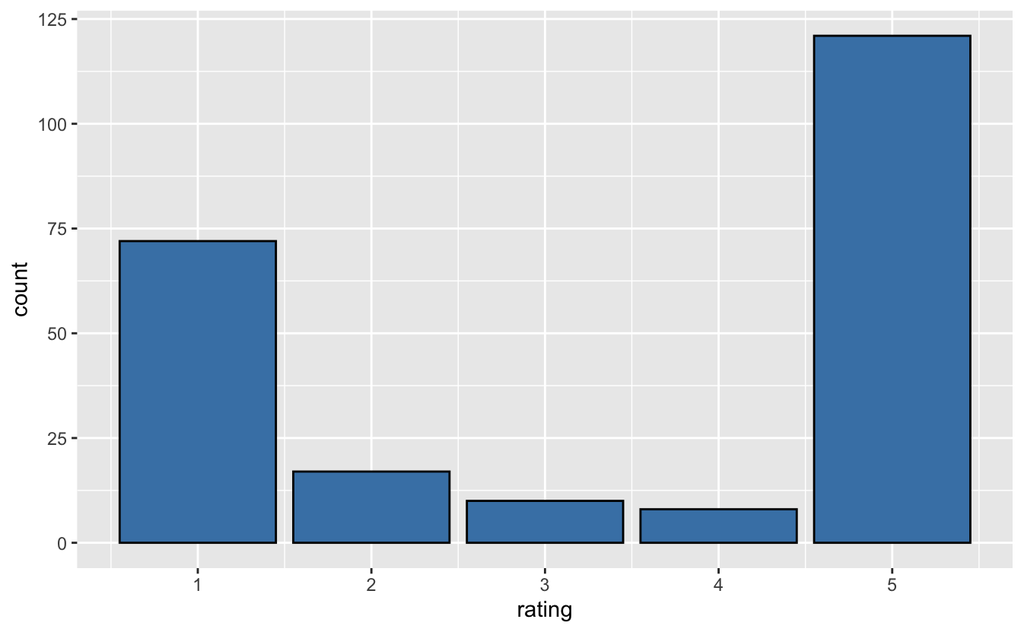

```r
#create a barchart to count the values
ggplot(data, aes(x=rating)) +
  geom_bar(color='black', fill='steelblue') +
  scale_fill_brewer(palette="Dark2")
```

```r
#create dataframe to build stacked barchart
rating <- c(1,2,3,4,5)
total <- c((sum(data$rating == 1)),
           (sum(data$rating == 2)),
          (sum(data$rating == 3)),
          (sum(data$rating == 4)),
          (sum(data$rating == 5)))

#create a table of all the rating sums
table3 <-data.frame(rating, total)
print(table3)
```

| rating | total |
| --- | --- |
| 1 | 72 |
| 2 | 17 |
| 3 | 10 |
| 4 | 8 |
| 5 | 121 |

The barchart is an tried and true plot used to plot discrete variales. Here, we see that the ratings from 2 to 4, in terms of count, are minimal comapred to 1 and 5;with the 5 rating being the most popular amongnst the reviewers. Next is to see the distribution of such.